**Nome:** Matheus Guerreiro Bulhões

**Email:** matheus_uefacl@hotmail.com

**Github:** https://github.com/matheus-1095

# 0.0 Imports

```python
!pip install Boruta --quiet
!pip install shap --quiet
```

```python
!jupyter nbconvert --to html matheus_guerreiro_teste_shape.ipynb
```

```
[NbConvertApp] Converting notebook matheus_guerreiro_teste_shape.ipynb to html
[NbConvertApp] WARNING | Alternative text is missing on 25 image(s).
[NbConvertApp] Writing 2635767 bytes to matheus_guerreiro_teste_shape.html
```

```python
import pandas as pd
import numpy as np
import seaborn as sns
import math
import shap
import datetime

from imblearn.over_sampling import SMOTE

from matplotlib import pyplot as plt
from matplotlib import gridspec
from scipy import stats as ss
from scipy.stats import shapiro, levene
from boruta import BorutaPy

from sklearn.model_selection import train_test_split, cross_validate, GridSearchCV
from sklearn.preprocessing import RobustScaler, MinMaxScaler, LabelEncoder
from sklearn.metrics import accuracy_score, roc_auc_score, RocCurveDisplay, confusion_matrix, ConfusionMatrixDisplay, precision_score, recall_score, f1_score
from sklearn.tree import DecisionTreeClassifier
from sklearn.ensemble import RandomForestClassifier, RandomForestRegressor
from sklearn.linear_model import LogisticRegression
from xgboost import XGBClassifier

from IPython.core.display import HTML
from IPython.core.display import Image

from google.colab import drive

import warnings
warnings.filterwarnings('ignore')
```

## 0.1 Helper Functions

```python
def jupyter_settings():
    %matplotlib inline

    plt.style.use( 'bmh' )
    plt.rcParams['figure.figsize'] = [15, 8]
    plt.rcParams['font.size'] = 24
    display( HTML( '<style>.container { width:100% !important; }</style>') )
    pd.options.display.max_columns = None
    pd.options.display.max_rows = None
    pd.set_option( 'display.expand_frame_repr', False )
    sns.set()


jupyter_settings()
drive.mount('/content/drive')

def chi_sq_test(cross_tabs, m):
    """
    Prints the Chi-Squared Statistic, p-value, degress of freedom from a Chi-Squared test,
    and Cramer coefficient

    Args:
        cross_tabs: A crosstab dataframe.
    """
    chi2, p, dof, con_table = ss.chi2_contingency(cross_tabs)
    print(f"chi-squared = {chi2}")
    print(f"p value = {p}")
    print(f"degrees of freedom = {dof}")
    print(f"{m} coefficient = {ss.contingency.association(cross_tabs, method=m)}\n\n")


# Função adaptada
def run_mann_whitney_with_plot(df, target, vars_list):
    p_values = []

    for var in vars_list:
        group_0 = df[df[target] == 0][var].dropna()
        group_1 = df[df[target] == 1][var].dropna()

        stat, p = mannwhitneyu(group_0, group_1, alternative='two-sided')
        p_values.append(p)

        print(f"-> Mann-Whitney U test for {var} with target '{target}'")
        print(f"U statistic = {stat:.2e}")
        print(f"p-value = {p:.2e}")

        if p < 0.05:
            print(f"❗ Diferença estatisticamente significativa entre os grupos de '{target}' para '{var}'\n")
        else:
            print(f"✔️ Sem diferença estatisticamente significativa entre os grupos de '{target}' para '{var}'\n")


def bar_plot(
    figsize, title, data, x, y, xlabel=None, ylabel=None,
    palette=None, subtitle=None, hue=None, hue_title=None,
    legend_loc='best', padding=0, ax=None, order=None
):
    """
    Plots a bar plot using seaborn.

    Parâmetros:
        figsize (tuple): figure size (width, height)
        title (str): main title for plot
        data (DataFrame): dataframe with data to plot
        x (str): x axis column
        y (str): y axis column
        xlabel (str, optional): x axis label (default: None)
        ylabel (str, optional): y axis label (default: None)
        palette (str ou lista, optional): color palette for plot elements (default: None)
        subtitle (str, optional): subtitle for plot (default: None)
        hue (str, optional): column to be grouped (default: None)
        hue_title (str, optional): title for group legend (default: None)
        legend_loc (str ou tupla, optional): group legend location (default: 'best')
        padding (float, optional): spacing between label and bar label (default: 0)
        ax (Axes, optional): subplot instance to plot (default: None)
        order (list, optional): Order of bars (default: None)
    """

    if ax is None:
        # Cria a figura para o gráfico
        fig = plt.figure(figsize=figsize)
        ax = fig.add_subplot()
    else:
        # Usa a subplot fornecida
        fig = ax.get_figure()

    # Título e subtítulo alinhados à direita com ajuste de espaçamento
    fig.suptitle(title, fontsize=14, y=1.03)

    ax.set_title(subtitle, fontsize=10, fontstyle='italic')

    # Gráfico de barras
    ax = sns.barplot(data=data, x=x, y=y, errorbar=None, palette=palette, hue=hue, ax=ax, order=order)

    # Rótulos do eixo
    ax.set_xlabel(xlabel)
    ax.set_ylabel(ylabel)

    # Adiciona rótulos nas barras
    for c in ax.containers:
        ax.bar_label(
            c, fmt=lambda x: f"{x:0.0f}%" if x > 0 else "",
            padding=padding, color="White", fontweight="bold"
        )

    # Adiciona títulos na legenda (hue)
    if hue:
        handles, labels = ax.get_legend_handles_labels()
        ax.legend(handles, labels, title=hue_title, loc=legend_loc)


#Dicionário de cores
fail_palette = {
    'fail': 'red',
    'success': '#555555'
}

#Dicionário de cores
fail_palette_all = {
    True: 'red',
    False: '#555555'
}
```

## 0.2 Loading Data

```python
df = pd.read_excel('/content/drive/MyDrive/Shape Case DS/Test O_G_Equipment_Data.xlsx')
```

```python
df.head()
```

|  | Cycle | Preset_1 | Preset_2 | Temperature | Pressure | VibrationX | VibrationY | VibrationZ | Frequency | Fail |
| --- | --- | --- | --- | --- | --- | --- | --- | --- | --- | --- |
| 0 | 1 | 3 | 6 | 44.235186 | 47.657254 | 46.441769 | 64.820327 | 66.454520 | 44.483250 | False |
| 1 | 2 | 2 | 4 | 60.807234 | 63.172076 | 62.005951 | 80.714431 | 81.246405 | 60.228715 | False |
| 2 | 3 | 2 | 1 | 79.027536 | 83.032190 | 82.642110 | 98.254386 | 98.785196 | 80.993479 | False |
| 3 | 4 | 2 | 3 | 79.716242 | 100.508634 | 122.362321 | 121.363429 | 118.652538 | 80.315567 | False |
| 4 | 5 | 2 | 5 | 39.989054 | 51.764833 | 42.514302 | 61.037910 | 50.716469 | 64.245166 | False |

# 1.0 Data Description

```python
df1 = df.copy()
```

## 1.1 Data Dimensions

```python
print('Number of rows: {}'.format(df1.shape[0]))
print('Number of columns: {}'.format(df1.shape[1]))
```

```
Number of rows: 800
Number of columns: 10
```

## 1.2 Data Types

```python
df1.dtypes
```

|  | 0 |
| --- | --- |
| Cycle | int64 |
| Preset_1 | int64 |
| Preset_2 | int64 |
| Temperature | float64 |
| Pressure | float64 |
| VibrationX | float64 |
| VibrationY | float64 |
| VibrationZ | float64 |
| Frequency | float64 |
| Fail | bool |

**dtype:** object

```python
# Categorical variables
df1['Preset_1'] = df1['Preset_1'].astype(str)
df1['Preset_2'] = df1['Preset_2'].astype(str)
```

## 1.3 Check NA

```python
df1.isna().sum()
```

|  | 0 |
| --- | --- |
| Cycle | 0 |
| Preset_1 | 0 |
| Preset_2 | 0 |
| Temperature | 0 |
| Pressure | 0 |
| VibrationX | 0 |
| VibrationY | 0 |
| VibrationZ | 0 |
| Frequency | 0 |
| Fail | 0 |

**dtype:** int64

## 1.4 Descriptive Stats

```python
num_attributes = df1.select_dtypes(include=['int64', 'float64'])
cat_attributes = df1.select_dtypes(exclude=['int64', 'float64'])

# Central Tendency - mean, median
ct1_mean = pd.DataFrame(num_attributes.apply(np.mean)).T
ct2_median = pd.DataFrame(num_attributes.apply(np.median)).T

# Dispersion - std, min, max, range, skew, kurtosis
d1_std = pd.DataFrame(num_attributes.apply(np.std)).T
d2_min = pd.DataFrame(num_attributes.apply(min)).T
d3_max = pd.DataFrame(num_attributes.apply(max)).T
d4_range = pd.DataFrame(num_attributes.apply(lambda x: x.max() - x.min())).T
d5_skew = pd.DataFrame(num_attributes.apply(lambda x: x.skew())).T
d6_kurtosis = pd.DataFrame(num_attributes.apply(lambda x: x.kurtosis())).T

# Concatenate
m = pd.concat([d2_min, d3_max, d4_range, ct1_mean, ct2_median, d1_std, d5_skew, d6_kurtosis]).T.reset_index()
m.columns = ['attributes', 'min', 'max', 'range', 'mean', 'median', 'std', 'skew', 'kurtosis']
m
```

|  | attributes | min | max | range | mean | median | std | skew | kurtosis |
| --- | --- | --- | --- | --- | --- | --- | --- | --- | --- |
| 0 | Cycle | 1.000000 | 800.000000 | 799.000000 | 400.500000 | 400.500000 | 230.939927 | 0.000000 | -1.200000 |
| 1 | Temperature | 2.089354 | 255.607829 | 253.518475 | 69.263494 | 65.906716 | 25.520287 | 1.567258 | 7.233825 |
| 2 | Pressure | 3.480279 | 189.995681 | 186.515402 | 78.997945 | 75.014848 | 32.481514 | 0.546177 | 0.157602 |
| 3 | VibrationX | 3.846343 | 230.861142 | 227.014799 | 73.860275 | 69.394953 | 31.210107 | 1.160931 | 2.738741 |
| 4 | VibrationY | 10.057744 | 193.569947 | 183.512203 | 72.786878 | 65.504770 | 32.719277 | 0.745894 | 0.309591 |
| 5 | VibrationZ | 18.784169 | 230.951134 | 212.166966 | 71.866211 | 69.319237 | 27.827208 | 0.856152 | 1.658464 |
| 6 | Frequency | 4.380101 | 178.090303 | 173.710202 | 68.223449 | 65.664252 | 29.120485 | 0.349476 | -0.265309 |

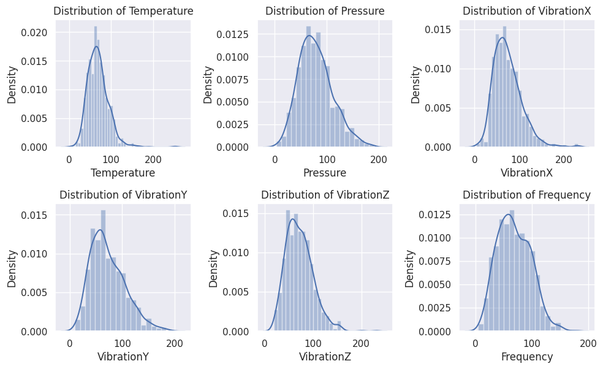

```python
# Select numerical attributes excluding 'Cycle'
numerical_cols = df1.select_dtypes(include=['int64', 'float64']).columns.tolist()
numerical_cols.remove('Cycle')

# Define grid size
n_cols = 3
n_rows = math.ceil(len(num_attributes) / n_cols)

# Create subplots
fig = plt.figure(figsize=(10, 3 * n_rows))
gs = gridspec.GridSpec(n_rows, n_cols)

for i, col in enumerate(numerical_cols):
    ax = fig.add_subplot(gs[i // n_cols, i % n_cols])
    sns.distplot(df1[col], kde=True, ax=ax)
    ax.set_title(f'Distribution of {col}')

plt.tight_layout()
plt.show()
```

```python
df1.columns
```

```
Index(['Cycle', 'Preset_1', 'Preset_2', 'Temperature', 'Pressure',
       'VibrationX', 'VibrationY', 'VibrationZ', 'Frequency', 'Fail'],
      dtype='object')
```

# 2.0 Train-Test Split

```python
df2 = df1.copy()
df_train, df_test = train_test_split(df2, test_size = 0.2, random_state=42)
```

```python
print(f"Train set: {df_train.shape}")
print(f"Test set:  {df_test.shape}")
```

```
Train set: (640, 10)
Test set:  (160, 10)
```

[figure not shown]

```python
Image("/content/drive/MyDrive/Shape Case DS/Hyphotesis Map.png")
```

## 2.1 Shape Digital Business Questions

**1.** How many times the equipment has failed?

**2.** How do the variables Preset_1 and Preset_2 behave during operation? What insights can we derive from these variables?

**3.** Categorize equipment failures by their nature/root cause according to parameter readings (temperature, pressure, and others).

# 3.0 Exploratory Data Analysis

```python
df3 = df_train.copy()

dict_fail = {
    True: "fail",
    False: "success",
}

df3 = df3.replace(dict_fail)
```

## 3.1 Frequency Target Variable

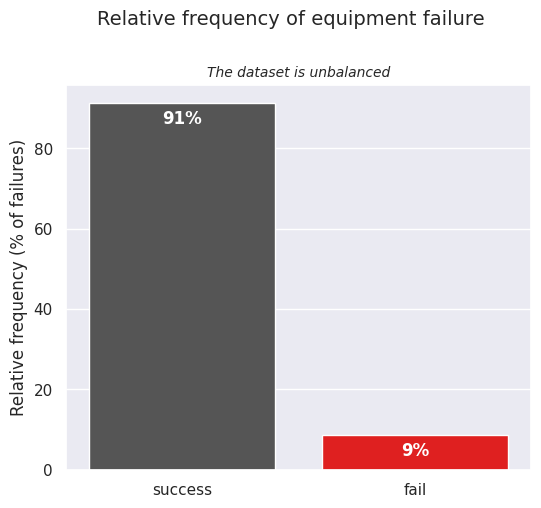

```python
df_freq_fail = df_train['Fail'].value_counts(normalize=True).mul(100).round(2).rename('percent').reset_index()

# Map boolean Fail values to strings 'success' and 'fail'
df_freq_fail['Fail'] = df_freq_fail['Fail'].map(dict_fail)

bar_plot(
    (6, 5),
    'Relative frequency of equipment failure',
    df_freq_fail,
    x = 'Fail',
    y = 'percent',
    ylabel='Relative frequency (% of failures)',
    subtitle='The dataset is unbalanced',
    palette = fail_palette,
    padding=-18
)
```

## 3.2 Shape Business Answers

### 3.2.1 How many times the equipment has failed?

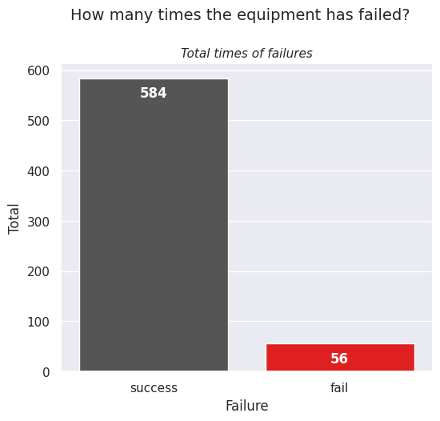

```python
df_freq_fail = df3['Fail'].value_counts().rename('total').reset_index()

# Create bar plot
plt.figure(figsize=(6, 5))
ax = sns.barplot(x='Fail', y='total', data=df_freq_fail, palette=fail_palette) # Using fail_palette as it has string keys
plt.suptitle('How many times the equipment has failed?', y=1.02, fontsize=14)
ax.set_title('Total times of failures', fontsize=11, fontstyle='italic')
plt.xlabel('Failure')
plt.ylabel('Total')

# Add labels
for container in ax.containers:
    ax.bar_label(container, fmt='%d', color='white', fontweight='bold', padding=-20)

plt.show()
```

### 3.2.2 How do the variables Preset_1 and Preset_2 behave during operation? What insights can we derive from these variables?

#### 3.2.2.1 Pre_set 1

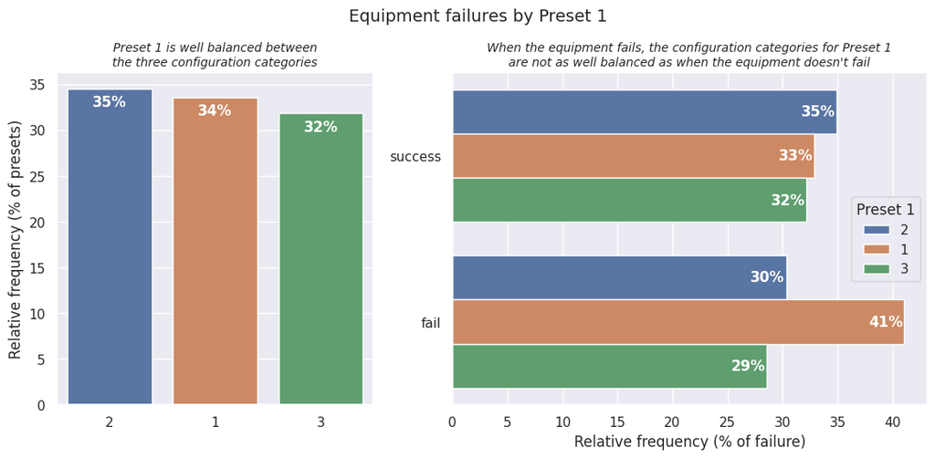

```python
df_freq_preset_1 = df_train["Preset_1"].value_counts(normalize=True).mul(100).round(2).rename("percent").reset_index()

df_by_preset1 = df_train.groupby("Fail")["Preset_1"].value_counts(normalize=True).mul(100).round(2).rename("percent").reset_index()

# Map boolean Fail values to strings 'success' and 'fail'
df_by_preset1['Fail'] = df_by_preset1['Fail'].map(dict_fail)


fig, axes = plt.subplots(1, 2, figsize=(13, 5), width_ratios=[1, 1.5])

bar_plot(
    (6, 5),
    "",
    df_freq_preset_1,
    x = "Preset_1",
    y = "percent",
    ylabel="Relative frequency (% of presets)",
    subtitle="Preset 1 is well balanced between\nthe three configuration categories",
    palette = "deep",
    padding=-18,
    ax=axes[0]
)

bar_plot(
    (8, 5),
    "Equipment failures by Preset 1",
    df_by_preset1,
    y="Fail",
    x="percent",
    xlabel="Relative frequency (% of failure)",
    palette = "deep",
    subtitle = "When the equipment fails, the configuration categories for Preset 1\nare not as well balanced as when the equipment doesn't fail",
    hue="Preset_1",
    hue_title="Preset 1",
    legend_loc="center right",
    padding=-30,
    ax=axes[1]
)
```

#### 3.2.2.2 Pre_set 2

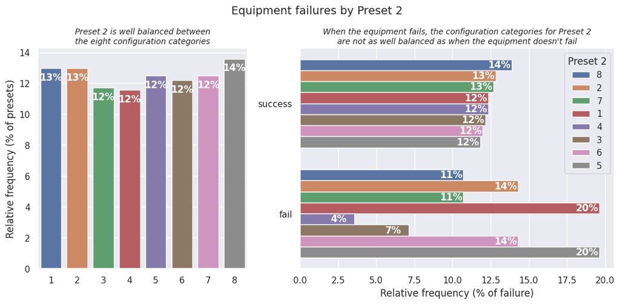

```python
df_freq_preset_2 = df_train["Preset_2"].value_counts(normalize=True).mul(100).round(2).rename("percent").reset_index()

df_by_preset2 = df_train.groupby("Fail")["Preset_2"].value_counts(normalize=True).mul(100).round(2).rename("percent").reset_index()
df_by_preset2['Fail'] = df_by_preset2['Fail'].map(dict_fail)

fig, axes = plt.subplots(1, 2, figsize=(13, 5), width_ratios=[1, 1.5])

# Get the unique values of Preset_2 and sort them for ordering the bars
preset2_order = sorted(df_train['Preset_2'].unique())

bar_plot(
    (6, 5),
    "",
    df_freq_preset_2,
    x = "Preset_2",
    y = "percent",
    ylabel="Relative frequency (% of presets)",
    subtitle="Preset 2 is well balanced between\nthe eight configuration categories",
    palette = "deep",
    padding=-18,
    ax=axes[0],
    order=preset2_order  # Add order here
)


bar_plot(
    (8, 5),
    "Equipment failures by Preset 2",
    df_by_preset2,
    y="Fail",
    x="percent",
    xlabel="Relative frequency (% of failure)",
    palette = "deep",
    subtitle = "When the equipment fails, the configuration categories for Preset 2\nare not as well balanced as when the equipment doesn't fail",
    hue="Preset_2",
    hue_title="Preset 2",
    legend_loc="upper right",
    padding=-30,
    ax=axes[1]
)
```

#### 3.2.2.3 Pre-set 1 and Pre-set 2

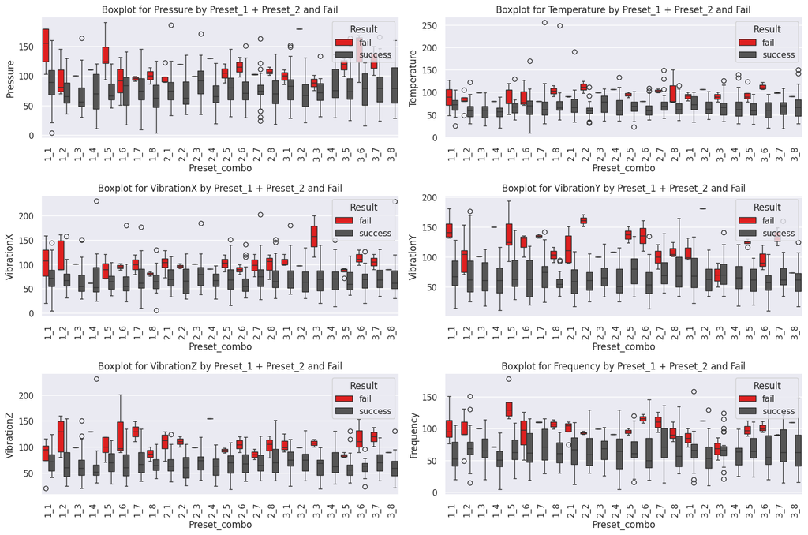

```python
# Criar uma nova coluna combinando Preset_1 e Preset_2 (como string)
df3['Preset_combo'] = df3['Preset_1'].astype(str) + "_" + df3['Preset_2'].astype(str)

# Variable list
sensor_vars = ['Pressure', 'Temperature', 'VibrationX', 'VibrationY', 'VibrationZ', 'Frequency']

# Sort the unique values of Preset_combo for ordering the x-axis
preset_combo_order = sorted(df3['Preset_combo'].unique())

# Define grid size
n_cols = 2
n_rows = 3

# Create subplots
fig, axes = plt.subplots(n_rows, n_cols, figsize=(15, 10))
axes = axes.flatten()  # Flatten the 2D array of axes for easy iteration

# Create boxplots in grid per variable
for i, var in enumerate(sensor_vars):
    ax = axes[i]
    sns.boxplot(
        data=df3,
        x='Preset_combo',
        y=var,
        hue='Fail',
        palette=fail_palette,
        order=preset_combo_order,  # Add order here
        ax=ax
    )
    ax.set_xticklabels(ax.get_xticklabels(), rotation=90)
    ax.set_title(f"Boxplot for {var} by Preset_1 + Preset_2 and Fail")
    ax.set_xlabel("Preset_combo")
    ax.set_ylabel(var)
    ax.legend(title='Result', loc='upper right')


plt.tight_layout()
plt.show()
```

```python
# Create the 'Preset_combo' column on the original dataframe df1
df1['Preset_combo'] = df1['Preset_1'].astype(str) + "_" + df1['Preset_2'].astype(str)

# Filtering for config '3 4' in the original dataframe
subset = df1[df1['Preset_combo'] == '3_4']

# Selecionar as variáveis desejadas
columns_to_summarize = ['Pressure', 'Temperature', 'Frequency',
                        'VibrationX', 'VibrationY', 'VibrationZ']

# Make the statiscial resume
summary = subset[columns_to_summarize].describe().T

summary.index.name = "Variables"

print("Summary of the variables from the original dataset: Config = 3_4")
display(summary)
```

```
Summary of the variables from the original dataset: Config = 3_4
```

| Variables | count | mean | std | min | 25% | 50% | 75% | max |
| --- | --- | --- | --- | --- | --- | --- | --- | --- |
| Pressure | 31.0 | 81.217122 | 33.115012 | 29.144016 | 55.879625 | 75.217615 | 110.935216 | 146.731223 |
| Temperature | 31.0 | 68.961346 | 28.039198 | 30.218279 | 47.414377 | 62.723044 | 81.167583 | 139.171489 |
| Frequency | 31.0 | 60.594080 | 23.137655 | 24.860102 | 45.091330 | 63.396592 | 70.351049 | 121.598046 |
| VibrationX | 31.0 | 71.300352 | 34.199306 | 12.762317 | 48.187802 | 70.645651 | 87.871765 | 149.718535 |
| VibrationY | 31.0 | 68.097788 | 25.863053 | 18.272366 | 47.600046 | 62.630151 | 85.109904 | 120.724162 |
| VibrationZ | 31.0 | 68.573582 | 25.520296 | 28.991121 | 50.444017 | 61.115042 | 89.205091 | 130.430205 |

```python
# qualitative associations
for var in cat_attributes:
    if var != 'Fail':
      print(f"-> Feature {var} with target 'Fail'")
      tabs1 = pd.crosstab(df_train["Fail"], df_train[var])
      chi_sq_test(tabs1, 'cramer')
```

```
-> Feature Preset_1 with target 'Fail'
chi-squared = 1.5412525683687348
p value = 0.46272318133467893
degrees of freedom = 2
cramer coefficient = 0.04907348711958574


-> Feature Preset_2 with target 'Fail'
chi-squared = 9.933263079440607
p value = 0.1923870435673064
degrees of freedom = 7
cramer coefficient = 0.1245821960057935
```

Statistical Interpretation:

**1.** **High p-value (> 0.05)**: Both tests fail to reject the null hypothesis.

This means there is insufficient statistical evidence to confirm an association between Preset_1 or Preset_2 and Failure. In simple terms: **failure patterns occur similarly regardless of the Preset value.**

**2.** **Cramér's V: Strength of Association** Typical Values:

- 0.00 - 0.10: Almost no association.
- 0.10 - 0.20: Weak association.
- 0.20 - 0.40: Moderate.
- '>=0.40: Strong.

*Results:*

**Preset_1:** 0.049 → Virtually no association.

**Preset_2:** 0.125 → Weak association, but not yet statistically significant.

**==================CONCLUSION=====================**

The tests indicate that none of the variables Preset_1 and Preset_2 present a statistically significant association with the occurrence of failure. The strength of association measured by Cramér's coefficient is weak for Preset_2 (0.12) and practically zero for Preset_1 (0.05), suggesting that these variables alone do not explain equipment failure well.

### 3.2.3 Categorize equipment failures by their nature/root cause according to parameter readings (temperature, pressure, and others).

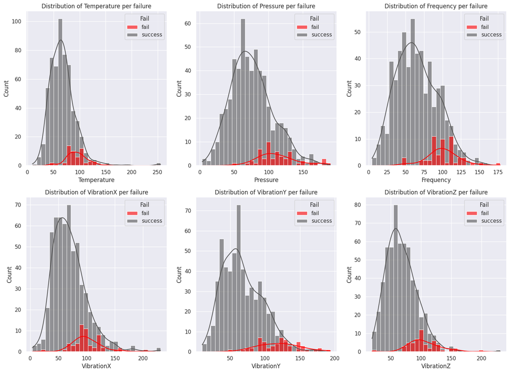

```python
#Variable list
sensor_vars = ['Temperature', 'Pressure', 'Frequency', 'VibrationX', 'VibrationY', 'VibrationZ']

# Create figure and axes 2x3
fig, axes = plt.subplots(nrows=2, ncols=3, figsize=(15, 11))
axes = axes.flatten()  # Utility function to easily iterate

for i, var in enumerate(sensor_vars):
    ax = axes[i]
    sns.histplot(data=df3, x=var, hue='Fail', kde=True, bins=30, multiple='layer', alpha=0.6, palette=fail_palette, ax=ax)
    ax.set_title(f'Distribution of {var} per failure')


plt.tight_layout()
plt.show()
```

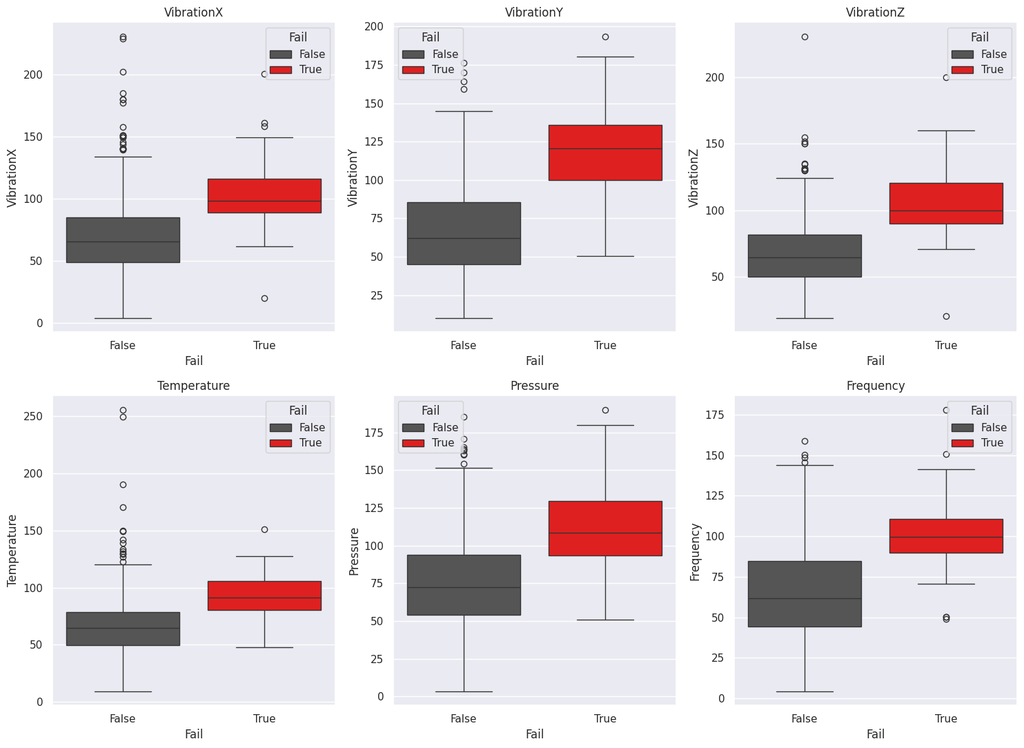

```python
metrics = ['VibrationX', 'VibrationY', 'VibrationZ', 'Temperature', 'Pressure', 'Frequency']

fig, axes = plt.subplots(nrows=2, ncols=3, figsize=(15, 11))
axes = axes.flatten()

for ax, metric in zip(axes, metrics):
    sns.boxplot(x='Fail', y=metric, data=df_train, ax=ax, hue='Fail', palette=fail_palette_all)
    ax.set_title(metric)
    ax.set_xlabel('Fail')
    ax.set_ylabel(metric)

plt.tight_layout()
plt.show()
```

```python
# Summary measures for quantitative independent features and label to search for relationships
for var in numerical_cols:
    print(f"Summary statistics for {var} grouped by Fail:")
    aggregated_stats = df3.groupby("Fail")[var].agg(["min", "max", "mean", "var", "std", "skew"])

    # Calculate kurtosis separately and add it
    kurtosis_values = df3.groupby("Fail")[var].apply(lambda x: x.kurtosis())
    aggregated_stats['kurtosis'] = kurtosis_values

    print(aggregated_stats)
    print("-------------------------------------------------------------------------------------\n")
```

```
Summary statistics for Temperature grouped by Fail:
               min         max       mean         var        std      skew   kurtosis
Fail
fail     48.091962  150.880308  93.952910  381.153475  19.523152  0.135354   0.962502
success   9.322154  255.607829  67.074581  636.575901  25.230456  2.018977  10.603831
-------------------------------------------------------------------------------------

Summary statistics for Pressure grouped by Fail:
               min         max        mean         var        std      skew  kurtosis
Fail
fail     50.822002  189.995681  113.756998  868.648737  29.472847  0.771129  0.537585
success   3.480279  185.406401   75.667147  940.451531  30.666782  0.517461  0.207478
-------------------------------------------------------------------------------------

Summary statistics for VibrationX grouped by Fail:
               min         max        mean         var        std      skew  kurtosis
Fail
fail     20.120467  200.749598  100.300915  746.011573  27.313212  0.837028  3.543220
success   3.846343  230.861142   70.136749  936.094872  30.595668  1.296536  3.357295
-------------------------------------------------------------------------------------

Summary statistics for VibrationY grouped by Fail:
               min         max        mean         var        std      skew  kurtosis
Fail
fail     50.481820  193.569947  120.271270  895.330487  29.922074  0.193181 -0.103442
success  10.057744  176.197917   67.477349  813.551159  28.522818  0.646052  0.205144
-------------------------------------------------------------------------------------

Summary statistics for VibrationZ grouped by Fail:
               min         max        mean         var        std      skew  kurtosis
Fail
fail     20.522642  200.242674  105.473703  774.771592  27.834719  0.570024  2.557372
success  18.784169  230.951134   67.667564  648.634615  25.468306  0.970646  2.736877
-------------------------------------------------------------------------------------

Summary statistics for Frequency grouped by Fail:
               min         max        mean         var        std      skew  kurtosis
Fail
fail     48.923777  178.090303  100.639693  516.639508  22.729705  0.435128  2.186555
success   4.380101  158.811673   65.144168  783.922147  27.998610  0.407143 -0.221317
-------------------------------------------------------------------------------------
```

```python
df3['Fail'] = df3['Fail'].map({'success': 0, 'fail': 1})

# quantitative associations for Mann-Whitney U Test
for var in numerical_cols:
    if var != 'Fail':
      print(f"-> Shapiro test for {var} with target 'Fail'")
      shapiro_0 = shapiro(df3[df3['Fail'] == 0][var])
      shapiro_1 = shapiro(df3[df3['Fail'] == 1][var])
      print(f"Fail = 0: p = {shapiro_0.pvalue:.7f}")
      print(f"Fail = 1: p = {shapiro_1.pvalue:.7f}\n")
```

```
-> Shapiro test for Temperature with target 'Fail'
Fail = 0: p = 0.0000000
Fail = 1: p = 0.0772831

-> Shapiro test for Pressure with target 'Fail'
Fail = 0: p = 0.0000020
Fail = 1: p = 0.0107423

-> Shapiro test for VibrationX with target 'Fail'
Fail = 0: p = 0.0000000
Fail = 1: p = 0.0008382

-> Shapiro test for VibrationY with target 'Fail'
Fail = 0: p = 0.0000000
Fail = 1: p = 0.8820226

-> Shapiro test for VibrationZ with target 'Fail'
Fail = 0: p = 0.0000000
Fail = 1: p = 0.0037520

-> Shapiro test for Frequency with target 'Fail'
Fail = 0: p = 0.0000060
Fail = 1: p = 0.0223953
```

📊 Interpretation of Results

1. Temperature

Failure = 0: p ≈ 0.0000 → ❌ Non-normal

Failure = 1: p ≈ 0.077 → ✅ Distribution close to normal

🔍 Conclusion: Temperature behaves differently between classes. It may have relevant predictive value.

2. Pressure

Fail = 0: p ≈ 0.000002 → ❌ Non-normal

Fail = 1: p ≈ 0.0107 → ❌ Non-normal

## 🔍 Conclusion: Both groups are not normally distributed → This may hinder linear models (e.g., logistic regression without transformation)

3. VibrationX

Both p < 0.001 → ❌ Non-normal

🔍 Conclusion: Non-normal in both groups → may also impact models sensitive to normality

4. VibrationY

Fail = 0: p ≈ 0.0000 → ❌ Non-normal

Fail = 1: p ≈ 0.88 → ✅ Normal

🔍 Conclusion: Different statistical behavior between classes. This may help the model differentiate between success and failure.

5. VibrationZ

Both p < 0.005 → ❌ Non-normal

🔍 Conclusion: No normality in both groups

6. Frequency

Both p < 0.05 → ❌ Non-normal

🔍 Conclusion: Frequency also behaves non-normally in both groups.

Conclusions:

```python
# quantitative associations for Levene Test
for var in numerical_cols:
    if var != 'Fail':
      print(f"-> Levene test for {var} with target 'Fail'")
      stat, p = levene(
      df3[df3['Fail'] == 0][var],
      df3[df3['Fail'] == 1][var]
      )
      print(f"Levene p-value: {p:.4f}\n\n")
```

```
-> Levene test for Temperature with target 'Fail'
Levene p-value: 0.2041


-> Levene test for Pressure with target 'Fail'
Levene p-value: 0.4908


-> Levene test for VibrationX with target 'Fail'
Levene p-value: 0.1745


-> Levene test for VibrationY with target 'Fail'
Levene p-value: 0.6895


-> Levene test for VibrationZ with target 'Fail'
Levene p-value: 0.9541


-> Levene test for Frequency with target 'Fail'
Levene p-value: 0.0051
```

Levene's test assesses whether the variance of the variables is similar between the two target classes (Fail = 0 and Fail = 1).

✅ Variables with homogeneous variances (p > 0.05): Temperature (p = 0.2041)

Pressure (p = 0.4908)

Vibration X (p = 0.1745)

Vibration Y (p = 0.6895)

Vibration Z (p = 0.9541)

These variables do not violate the assumption of homogeneity of variance, making them suitable for parametric tests (such as ANOVA) if normality is also met.

❌ Variable with heterogeneous variance (p < 0.05): Frequency (p = 0.0051)

The Frequency variable presents significant differences in variance between failure classes, indicating heteroscedasticity. This can impact traditional parametric analyses, requiring robust tests or data transformations.

Based on the test results:

📌 1. Shapiro-Wilk test (normality): Most variables do not follow a normal distribution (p < 0.05 in many cases).

Example: Temperature, Pressure, VibrationX, VibrationZ, Frequency (for at least one of the classes) showed violations of normality.

📌 2. Levene's test (homogeneity of variance): Only the Frequency variable showed heterogeneity of variance (p < 0.05), but normality was also violated in other variables.

```python
from scipy.stats import mannwhitneyu

# Continuous variables list
continuous_vars = ['Temperature', 'Pressure', 'VibrationX', 'VibrationY', 'VibrationZ', 'Frequency']

# Execute Mann Whitney U test
run_mann_whitney_with_plot(df3, target='Fail', vars_list=continuous_vars)
```

```
-> Mann-Whitney U test for Temperature with target 'Fail'
U statistic = 5.38e+03
p-value = 1.00e-16
❗ Diferença estatisticamente significativa entre os grupos de 'Fail' para 'Temperature'

-> Mann-Whitney U test for Pressure with target 'Fail'
U statistic = 5.76e+03
p-value = 1.11e-15
❗ Diferença estatisticamente significativa entre os grupos de 'Fail' para 'Pressure'

-> Mann-Whitney U test for VibrationX with target 'Fail'
U statistic = 6.33e+03
p-value = 3.42e-14
❗ Diferença estatisticamente significativa entre os grupos de 'Fail' para 'VibrationX'

-> Mann-Whitney U test for VibrationY with target 'Fail'
U statistic = 3.40e+03
p-value = 1.11e-22
❗ Diferença estatisticamente significativa entre os grupos de 'Fail' para 'VibrationY'

-> Mann-Whitney U test for VibrationZ with target 'Fail'
U statistic = 4.51e+03
p-value = 3.20e-19
❗ Diferença estatisticamente significativa entre os grupos de 'Fail' para 'VibrationZ'

-> Mann-Whitney U test for Frequency with target 'Fail'
U statistic = 5.34e+03
p-value = 8.00e-17
❗ Diferença estatisticamente significativa entre os grupos de 'Fail' para 'Frequency'
```

The Mann-Whitney U test confirms that, for all variables analyzed, the distributions are significantly different between the failure and non-failure groups. This reinforces the following:

These variables have significant predictive potential in the model.

The differences are not due to chance but are statistically robust.

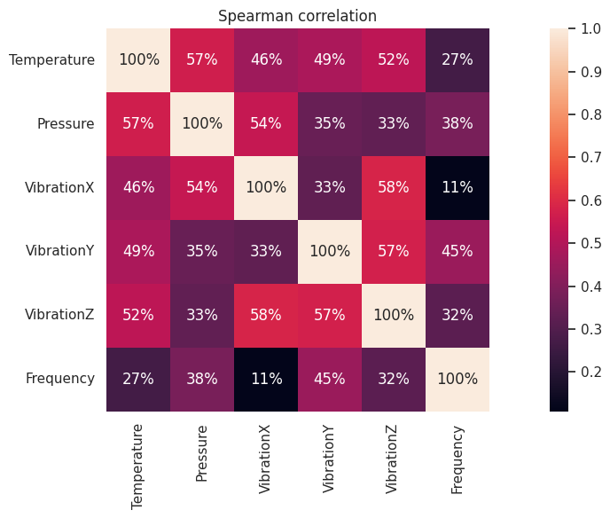

```python
spearman_corr = df3[numerical_cols].corr(method='spearman')

fig, ax1 = plt.subplots(figsize=(14,6))

sns.heatmap(spearman_corr, fmt='.0%', annot=True, square=True, ax=ax1)
ax1.set_title("Spearman correlation")

plt.tight_layout()
```

**Main relationships observed:**

🔷 Temperature

- With Pressure → 0.57 → Moderate positive: The higher the temperature, the higher the pressure tends to be.
- With Vibrations:
- VibrationX → 0.46 (moderate)
- VibrationY → 0.49 (moderate)
- VibrationZ → 0.52 (moderate)
- With Frequency → 0.27 (weak)

📌 Conclusion: Temperature has a moderate correlation with pressure and vibrations.

🔷 Pressure

- With VibrationX → 0.54 (moderate)
- With Frequency → 0.38 (weak)
- With other vibrations: VibrationY (0.35), VibrationZ (0.33) → weak

📌 Conclusion: Pressure is more closely related to VibrationX than to VibrationY and Z.

🔷 Vibrations among themselves

- VibrationX vs VibrationZ → 0.58 → moderate/strong
- VibrationY vs VibrationZ → 0.57 → moderate
- VibrationX vs VibrationY → 0.33 → weak

📌 Conclusion: VibrationZ appears to be the common point with the strongest correlations with other vibrations.

🔷 Frequency

- With VibrationY → 0.45 → moderate
- With other variables: all weak or very weak

*Ex.: VibrationX → 0.11 → virtually no correlation*

📌 Conclusion: Frequency appears to have little or no association with most variables (except VibrationY).

🔎 Overall Conclusion: There are moderate correlations between several variables, especially between:

- Temperature and Pressure
- Temperature and Vibrations
- Among vibrations, especially with VibrationZ
- Frequency has a weaker relationship with the others, with VibrationY standing out.

# 4.0 Data Preparation

```python
df4 = df_train.copy().reset_index(drop=True)
```

🔧 **Data Preparation – Feature Engineering Justification**

Below are the transformations applied to enhance the dataset and improve model performance, along with their justifications:

```python
# RMS of Vibration X, Y and Z (root mean square)
df4['Vibration_RMS'] = np.sqrt(df4['VibrationX']**2 + df4['VibrationY']**2 + df4['VibrationZ']**2)

# Data Transformation
old_cols_temp_press = ['Temperature', 'Pressure']
df4['Temp_Pressure'] = df4[old_cols_temp_press[0]] * df4[old_cols_temp_press[1]]
df4['Preset_1'] = df4['Preset_1'].astype(int)
df4['Preset_2'] = df4['Preset_2'].astype(int)
```

#### ✅ `Vibration_RMS` (Root Mean Square of Vibrations)

**Rationale:**  
In systems where vibration is measured in three axes (X, Y, Z), the overall vibration intensity is best represented by the Root Mean Square (RMS). This transformation combines the directional components into a single metric that reflects the total vibrational energy of the system.

**Why it matters:**  
This metric is widely used in industrial monitoring for machinery health and fault detection, as it provides a comprehensive measure of vibration severity, independent of direction.

#### ✅ `Temp_Pressure` (Interaction between Temperature and Pressure)

**Rationale:**  
Multiplying temperature and pressure creates an interaction feature that captures nonlinear relationships between the two variables. This is important because in physical and mechanical systems, the joint effect of temperature and pressure can significantly influence performance and failure risk.

**Why it matters:**  
This interaction term allows predictive models to learn more complex patterns that would not be captured by the variables independently.

#### ✅ Conversion of `Preset_1` and `Preset_2` to `int`

**Rationale:**  
These variables represent discrete operational configurations. Converting them to integers ensures they are treated as categorical numeric codes rather than continuous variables.

**Why it matters:**  
This step improves consistency and facilitates correct grouping, aggregation, and modeling behavior, particularly in classification tasks or when encoding is needed later.

## 4.1 Preprocessing

```python
# Changing the target variable to feed the model
dict_fail_model = {
    "fail": 1,
    "success": 0,
}

df4 = df4.replace(dict_fail_model)
df_test = df_test.replace(dict_fail_model)
```

```python
# Creating the feature matrix and target vector
X_train = df4.drop(columns=["Fail", 'Cycle'])
y_train = df_train["Fail"]
```

# 5.0 Feature Selection

```python
# Training and val dataset for Boruta
X_train_n = X_train.values # Specify to drop the 'Fail' column
y_train_n = y_train.values.ravel()

# Define RandomForestRegressor
rf = RandomForestRegressor(n_jobs=-1)

# Define Boruta
boruta = BorutaPy(rf, n_estimators='auto', verbose=2, random_state=42).fit(X_train_n, y_train_n)
cols_selected = boruta.support_.tolist()

# best features from boruta
# Select columns based on Boruta's selection
cols_selected_boruta = X_train.columns[cols_selected].tolist()
cols_not_selected_boruta = list(np.setdiff1d(X_train.columns, cols_selected_boruta))

print("Selected Features by Boruta:")
print(cols_selected_boruta)
print("\nFeatures Not Selected by Boruta:")
print(cols_not_selected_boruta)
```

[output not shown]

```python
# Get the ranks and median importances of the features determined by Boruta
feature_ranks = pd.DataFrame({
    'feature': X_train.columns,
    'rank': boruta.ranking_,
    'median_importance': boruta.ranking_ # This is not the actual median importance, but I will use the rank for now
})

# Get the median importance from the Boruta result for confirmed features (rank 1)
# This is a workaround as direct access to estimator_.feature_importances_ is not available
# We can filter for confirmed features and potentially use their median Z-score if needed,
# but for simplicity here we will just show the rank and note that rank 1 are the most "important"
feature_ranks = feature_ranks.sort_values(by='rank', ascending=True)

print("BORUTA - Feature Ranking:")
print(feature_ranks[['feature', 'rank']])

print("\nFeatures with Rank 1 (Considered Important by Boruta):")
print(feature_ranks[feature_ranks['rank'] == 1]['feature'].tolist())
```

```
BORUTA - Feature Ranking:
         feature  rank
3       Pressure     1
2    Temperature     1
7      Frequency     1
5     VibrationY     1
9  Temp_Pressure     1
8  Vibration_RMS     1
6     VibrationZ     2
4     VibrationX     3
1       Preset_2     4
0       Preset_1     5

Features with Rank 1 (Considered Important by Boruta):
['Pressure', 'Temperature', 'Frequency', 'VibrationY', 'Temp_Pressure', 'Vibration_RMS']
```

## 6.2 Comparing Feature Selection Methods

Now let's compare the features selected by Boruta and Feature Importance.

```python
# Define and train a RandomForestRegressor model
rf_importance = RandomForestRegressor(n_estimators=100, random_state=42, n_jobs=-1)
rf_importance.fit(X_train, y_train)

# Get feature importances
feature_importance = pd.DataFrame({
    'feature': X_train.columns,
    'importance': rf_importance.feature_importances_
})

# Sort by importance
feature_importance = feature_importance.sort_values(by='importance', ascending=False)

print("Feature Importance:")
print(feature_importance)
```

```
Feature Importance:
         feature  importance
8  Vibration_RMS    0.297087
7      Frequency    0.186944
5     VibrationY    0.137022
2    Temperature    0.105442
9  Temp_Pressure    0.102881
3       Pressure    0.085399
4     VibrationX    0.029538
6     VibrationZ    0.029112
1       Preset_2    0.017343
0       Preset_1    0.009231
```

```python
# final_decision = ['Vibration_RMS', 'Frequency', 'Temp_Pressure', 'Temperature', 'Pressure']
final_decision = ['Vibration_RMS', 'Frequency', 'Temp_Pressure']
X_train = X_train[final_decision]
```

To select the most relevant predictors for our machine learning model, we applied two complementary methods:

#### ✅ Boruta Feature Selection

**Outcome:**  
Boruta ranked the following variables as **important (Rank 1)**:

- `Pressure`
- `Temperature`
- `Frequency`
- `VibrationY`
- `Temp_Pressure`
- `Vibration_RMS`

#### ✅ Feature Importance (from Random Forest)

**Rationale:**  
We also computed classic feature importances from a Random Forest model. This provides a measure of how much each feature decreases the impurity in decision trees, and is a common technique for gauging the relative weight of each input variable.

**Top features by importance:**

- `Vibration_RMS` – 0.297
- `Frequency` – 0.187
- `VibrationY` – 0.137
- `Temperature` – 0.105
- `Temp_Pressure` – 0.103

### 🎯 Final Decision – Top 3 Features

- `Vibration_RMS` – Overall vibration magnitude
- `Frequency` – Operation frequency
- `Temp_Pressure` – Interaction between temperature and pressure

# 6.0 Machine Learning Algorithms

```python
X_train, X_val, y_train, y_val = train_test_split( X_train, y_train, test_size=0.2, random_state=42)
```

## 6.0.1 Oversampling

⚖️ Addressing Class Imbalance with SMOTE:

Before training the machine learning models, it is crucial to handle the class imbalance present in the target variable. Imbalanced data can lead to biased models that favor the majority class and fail to generalize well to minority class instances.

To mitigate this, I applied the SMOTE (Synthetic Minority Over-sampling Technique) method. SMOTE works by generating synthetic examples for the minority class based on feature-space similarities between existing minority instances. This improves the model's ability to learn decision boundaries for both classes.

```python
# Apply SMOTE to the training data
smote = SMOTE(random_state=42)
X_train_resampled, y_train_resampled = smote.fit_resample(X_train, y_train)

print("Shape of X_train before SMOTE:", X_train.shape)
print("Shape of X_train after SMOTE:", X_train_resampled.shape)
print("\nValue counts of y_train before SMOTE:")
print(y_train.value_counts())
print("\nValue counts of y_train after SMOTE:")
print(y_train_resampled.value_counts())
```

```
Shape of X_train before SMOTE: (512, 3)
Shape of X_train after SMOTE: (924, 3)

Value counts of y_train before SMOTE:
Fail
False    462
True      50
Name: count, dtype: int64

Value counts of y_train after SMOTE:
Fail
False    462
True     462
Name: count, dtype: int64
```

By applying SMOTE, I ensured a more balanced class distribution in the training set, which is essential for training robust classification models.

### 6.1 Decision Tree

As a baseline model, I first implemented a Decision Tree Classifier. Decision trees are intuitive and interpretable, making them a good starting point for understanding feature importance and basic model behavior. Although they tend to overfit on training data, they provide a useful benchmark for comparison against more complex models.

If more sophisticated models (e.g., Random Forest, XGBoost, Logistic Regression) demonstrate better generalization and predictive performance, the best-performing one will be selected for final deployment.

```python
# Initialize the Decision Tree Classifier
model = DecisionTreeClassifier(random_state=42)

# Create Metrics List
values = [i for i in range( 1, 20 )]
acc_scores = list()
prec_scores = list()
recall_scores = list()
f1_scores = list()

for i in values:
  model = DecisionTreeClassifier( max_depth=i )
  model.fit(X_train_resampled, y_train_resampled)
  y_val_pred = model.predict(X_val)

  # Calculate evaluation metrics using the validation set
  accuracy = accuracy_score(y_val, y_val_pred)
  precision = precision_score(y_val, y_val_pred)
  recall = recall_score(y_val, y_val_pred)
  f1 = f1_score(y_val, y_val_pred)

  acc_scores.append(accuracy)
  prec_scores.append(precision)
  recall_scores.append(recall)
  f1_scores.append(f1)

  # roc_auc = roc_auc_score(y_val, dt_model.predict_proba(X_val)[:, 1]) # ROC AUC needs probabilities
  # print(f"ROC AUC: {roc_auc_score:.4f}")

# Define the metrics for evaluation
scoring = ['accuracy', 'precision', 'recall', 'f1', 'roc_auc']

# Perform cross-validation
cv_results = cross_validate(
    model,
    X_train_resampled,
    y_train_resampled,
    cv=5,  # Using 5 folds for cross-validation
    scoring=scoring,
    return_train_score=False  # We are interested in validation scores
)

# Print the cross-validation results
print("Cross-validation results:")
for metric in scoring:
    mean_score = cv_results[f'test_{metric}'].mean()
    std_score = cv_results[f'test_{metric}'].std()
    print(f"{metric}: {mean_score:.4f} +/- {std_score:.4f}")
```

```
Cross-validation results:
accuracy: 0.9286 +/- 0.0276
precision: 0.9212 +/- 0.0264
recall: 0.9371 +/- 0.0319
f1: 0.9290 +/- 0.0278
roc_auc: 0.9286 +/- 0.0276
```

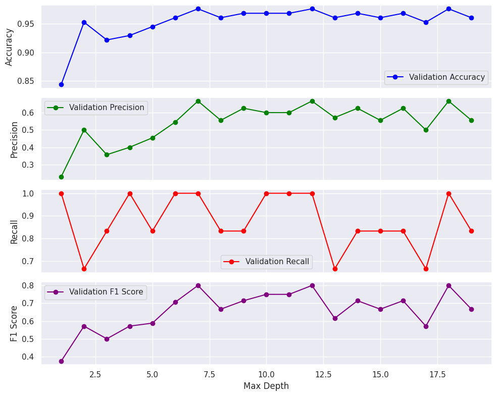

```python
## plot of train and test scores vs tree depth
fig, axes = plt.subplots(4, 1, figsize=(10, 8), sharex=True)

metrics = {
    'Accuracy': acc_scores,
    'Precision': prec_scores,
    'Recall': recall_scores,
    'F1 Score': f1_scores
}

colors = ['blue', 'green', 'red', 'purple']

for i, (metric_name, metric_values) in enumerate(metrics.items()):
    axes[i].plot(values, metric_values, '-o', label=f'Validation {metric_name}', color=colors[i])
    axes[i].set_ylabel(metric_name)
    axes[i].legend()
    if i == len(metrics) - 1:
        axes[i].set_xlabel('Max Depth')

plt.tight_layout()
plt.show()
```

```
Accuracy: 0.9609
Precision: 0.5556
Recall: 0.8333
F1 Score: 0.6667
ROC: 0.9993
---------------------------//--------------------------
```

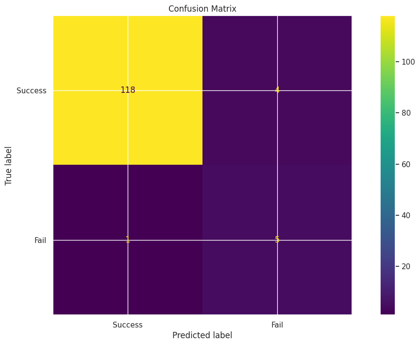

```python
# Display confusion matrix
model_last = DecisionTreeClassifier( max_depth=8 )
model_last.fit(X_train_resampled, y_train_resampled)
model_last.fit(np.concatenate( (X_train_resampled, X_val) ), np.concatenate((y_train_resampled, y_val)))
y_val_pred = model.predict(X_val)

# Calculate evaluation metrics using the validation set
accuracy = accuracy_score(y_val, y_val_pred)
precision = precision_score(y_val, y_val_pred)
recall = recall_score(y_val, y_val_pred)
f1 = f1_score(y_val, y_val_pred)
roc_auc = roc_auc_score(y_val, model_last.predict_proba(X_val)[:, 1])
print(f"Accuracy: {accuracy:.4f}")
print(f"Precision: {precision:.4f}")
print(f"Recall: {recall:.4f}")
print(f"F1 Score: {f1:.4f}")
print(f"ROC: {roc_auc:.4f}")
print('---------------------------//--------------------------\n\n')

cm = confusion_matrix(y_val, y_val_pred)
disp = ConfusionMatrixDisplay(confusion_matrix=cm, display_labels=['Success', 'Fail'])
disp.plot()
plt.title('Confusion Matrix')
plt.show()
```

### 6.2 RandomForest

Following the baseline model, I implemented a Random Forest Classifier. Random Forest is an ensemble learning method that builds multiple decision trees and merges their outputs to improve accuracy and reduce overfitting. It is particularly effective in handling noisy data and can capture nonlinear relationships.

Due to its robustness and ability to manage feature interactions, Random Forest often performs better than a single Decision Tree, especially in real-world classification problems with imbalanced datasets.

```python
# Initialize the RandomForest Classifier
model = RandomForestClassifier(random_state=42)

# Train the model

# Metrics list
values = [i for i in range( 1, 20 )]
acc_scores = list()
prec_scores = list()
recall_scores = list()
f1_scores = list()
roc_auc_scores = list()

for i in values:
  model = RandomForestClassifier( max_depth=i )
  model.fit(X_train_resampled, y_train_resampled)
  y_val_pred = model.predict(X_val)

  # Calculate evaluation metrics using the validation set
  accuracy = accuracy_score(y_val, y_val_pred)
  precision = precision_score(y_val, y_val_pred)
  recall = recall_score(y_val, y_val_pred)
  f1 = f1_score(y_val, y_val_pred)
  roc_auc = roc_auc_score(y_val, model.predict_proba(X_val)[:, 1]) # ROC AUC needs probabilities


  acc_scores.append(accuracy)
  prec_scores.append(precision)
  recall_scores.append(recall)
  f1_scores.append(f1)
  roc_auc_scores.append(roc_auc)

  # print(f"ROC AUC: {roc_auc_score:.4f}")

# Define the metrics for evaluation
scoring = ['accuracy', 'precision', 'recall', 'f1', 'roc_auc']

# Perform cross-validation
cv_results = cross_validate(
    model,
    X_train_resampled,
    y_train_resampled,
    cv=5,  # Using 5 folds for cross-validation
    scoring=scoring,
    return_train_score=False  # We are interested in validation scores
)

# Print the cross-validation results
print("Cross-validation results:")
for metric in scoring:
    mean_score = cv_results[f'test_{metric}'].mean()
    std_score = cv_results[f'test_{metric}'].std()
    print(f"{metric}: {mean_score:.4f} +/- {std_score:.4f}")
```

```
Cross-validation results:
accuracy: 0.9578 +/- 0.0105
precision: 0.9462 +/- 0.0241
recall: 0.9718 +/- 0.0224
f1: 0.9584 +/- 0.0101
roc_auc: 0.9875 +/- 0.0082
```

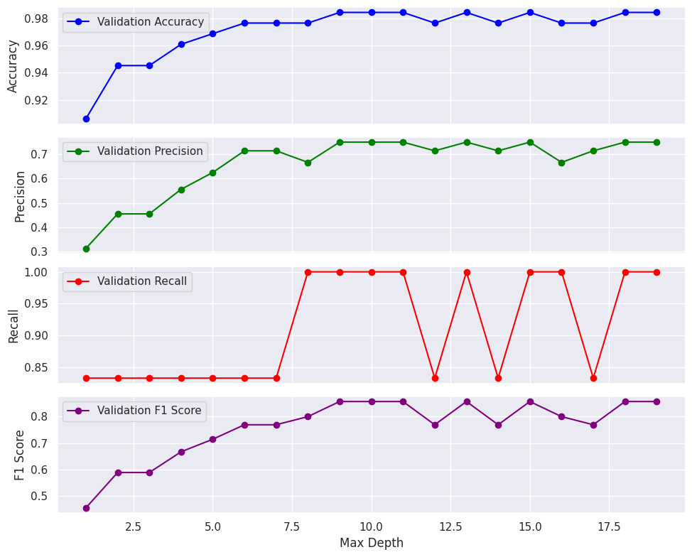

```python
## plot of train and test scores vs tree depth
fig, axes = plt.subplots(4, 1, figsize=(10, 8), sharex=True)

metrics = {
    'Accuracy': acc_scores,
    'Precision': prec_scores,
    'Recall': recall_scores,
    'F1 Score': f1_scores
}

colors = ['blue', 'green', 'red', 'purple']

for i, (metric_name, metric_values) in enumerate(metrics.items()):
    axes[i].plot(values, metric_values, '-o', label=f'Validation {metric_name}', color=colors[i])
    axes[i].set_ylabel(metric_name)
    axes[i].legend()
    if i == len(metrics) - 1:
        axes[i].set_xlabel('Max Depth')

plt.tight_layout()
plt.show()
```

```
Accuracy: 0.9844
Precision: 0.7500
Recall: 1.0000
F1 Score: 0.8571
ROC: 0.9932
---------------------------//--------------------------
```

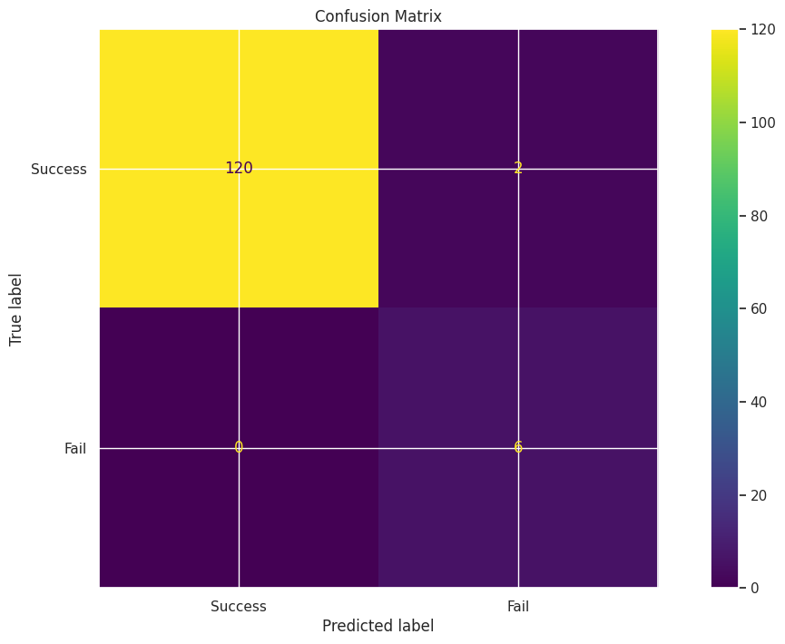

```python
# Display confusion matrix
model_last = RandomForestClassifier( max_depth=4 )
model_last.fit(X_train_resampled, y_train_resampled)
model_last.fit(np.concatenate( (X_train_resampled, X_val) ), np.concatenate((y_train_resampled, y_val)))
y_val_pred = model.predict(X_val)

# Calculate evaluation metrics using the validation set
accuracy = accuracy_score(y_val, y_val_pred)
precision = precision_score(y_val, y_val_pred)
recall = recall_score(y_val, y_val_pred)
f1 = f1_score(y_val, y_val_pred)
roc_auc = roc_auc_score(y_val, model_last.predict_proba(X_val)[:, 1])
print(f"Accuracy: {accuracy:.4f}")
print(f"Precision: {precision:.4f}")
print(f"Recall: {recall:.4f}")
print(f"F1 Score: {f1:.4f}")
print(f"ROC: {roc_auc:.4f}")
print('---------------------------//--------------------------\n\n')

cm = confusion_matrix(y_val, y_val_pred)
disp = ConfusionMatrixDisplay(confusion_matrix=cm, display_labels=['Success', 'Fail'])
disp.plot()
plt.title('Confusion Matrix')
plt.show()
```

### 6.3 XGBoost

To further improve performance, I applied XGBoost, a powerful gradient boosting algorithm known for its high efficiency and predictive accuracy. XGBoost builds decision trees sequentially, where each new tree aims to correct errors made by the previous ones.

XGBoost also includes regularization to prevent overfitting and has built-in handling of missing values, making it suitable for structured/tabular data like this dataset. Given its popularity in data science competitions and real-world applications, XGBoost is a strong candidate for final model selection.

```
Cross-validation results:
accuracy: 0.9567 +/- 0.0103
precision: 0.9385 +/- 0.0202
recall: 0.9783 +/- 0.0228
f1: 0.9576 +/- 0.0101
roc_auc: 0.9819 +/- 0.0051
```

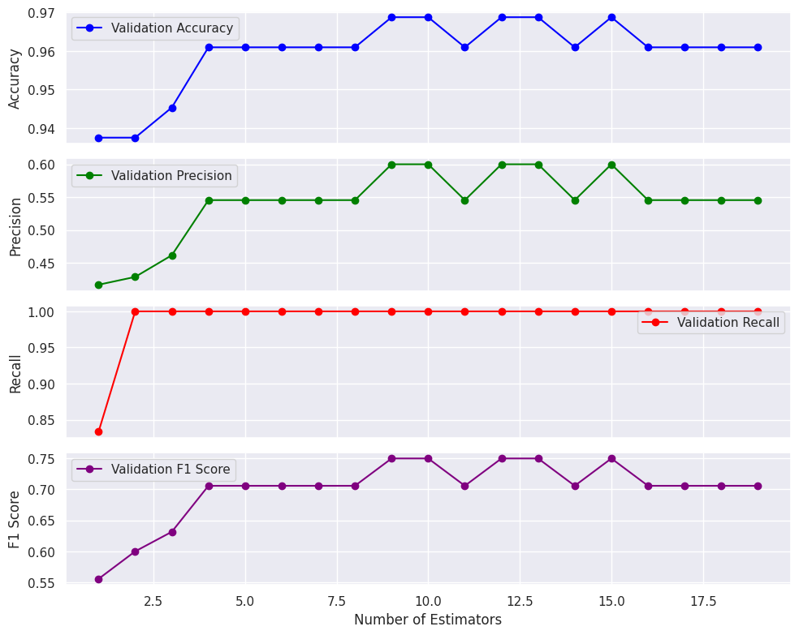

```python
# Initialize the XGBoost Classifier
model = XGBClassifier(random_state=42, use_label_encoder=False, eval_metric='logloss')

# Train the model

## Modelo treinado e validado com o dataset de Treinamento
values = [i for i in range(1, 20)]
acc_scores = list()
prec_scores = list()
recall_scores = list()
f1_scores = list()
roc_auc_scores = list()

for i in values:
  model = XGBClassifier(n_estimators=i, random_state=42, use_label_encoder=False, eval_metric='logloss')
  model.fit(X_train_resampled, y_train_resampled)
  y_val_pred = model.predict(X_val)

  # Calculate evaluation metrics using the validation set
  accuracy = accuracy_score(y_val, y_val_pred)
  precision = precision_score(y_val, y_val_pred)
  recall = recall_score(y_val, y_val_pred)
  f1 = f1_score(y_val, y_val_pred)
  roc_auc = roc_auc_score(y_val, model.predict_proba(X_val)[:, 1])


  acc_scores.append(accuracy)
  prec_scores.append(precision)
  recall_scores.append(recall)
  f1_scores.append(f1)
  roc_auc_scores.append(roc_auc)

# Define the metrics for evaluation
scoring = ['accuracy', 'precision', 'recall', 'f1', 'roc_auc']

# Perform cross-validation
cv_results = cross_validate(
    model,
    X_train_resampled,
    y_train_resampled,
    cv=5,  # Using 5 folds for cross-validation
    scoring=scoring,
    return_train_score=False  # We are interested in validation scores
)

# Print the cross-validation results
print("Cross-validation results:")
for metric in scoring:
    mean_score = cv_results[f'test_{metric}'].mean()
    std_score = cv_results[f'test_{metric}'].std()
    print(f"{metric}: {mean_score:.4f} +/- {std_score:.4f}")

## plot of train and test scores vs number of estimators
fig, axes = plt.subplots(4, 1, figsize=(10, 8), sharex=True)

metrics = {
    'Accuracy': acc_scores,
    'Precision': prec_scores,
    'Recall': recall_scores,
    'F1 Score': f1_scores
}

colors = ['blue', 'green', 'red', 'purple']

for i, (metric_name, metric_values) in enumerate(metrics.items()):
    axes[i].plot(values, metric_values, '-o', label=f'Validation {metric_name}', color=colors[i])
    axes[i].set_ylabel(metric_name)
    axes[i].legend()
    if i == len(metrics) - 1:
        axes[i].set_xlabel('Number of Estimators')

plt.tight_layout()
plt.show()
```

```
Accuracy: 0.9922
Precision: 0.8571
Recall: 1.0000
F1 Score: 0.9231
ROC: 0.9966
---------------------------//--------------------------
```

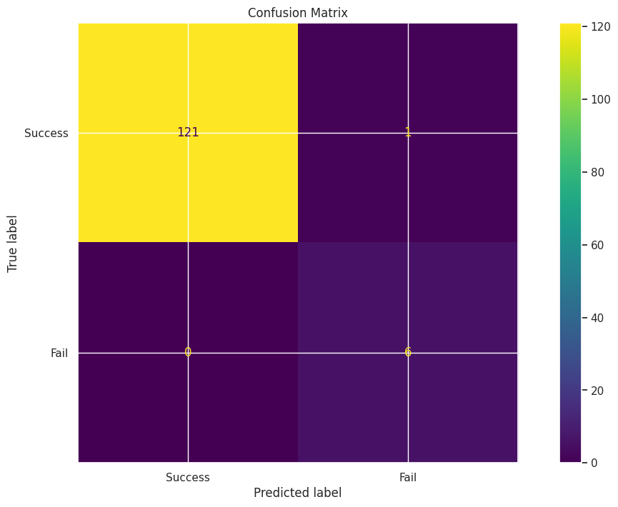

```python
# Display confusion matrix
model_last = XGBClassifier(n_estimators=6, random_state=42, use_label_encoder=False, eval_metric='logloss') # Using 3 estimators as an example, adjust based on plot
model_last.fit(np.concatenate( (X_train_resampled, X_val) ), np.concatenate((y_train_resampled, y_val)))
y_val_pred = model_last.predict(X_val)

# Calculate evaluation metrics using the validation set
accuracy = accuracy_score(y_val, y_val_pred)
precision = precision_score(y_val, y_val_pred)
recall = recall_score(y_val, y_val_pred)
f1 = f1_score(y_val, y_val_pred)
roc_auc = roc_auc_score(y_val, model_last.predict_proba(X_val)[:, 1])
print(f"Accuracy: {accuracy:.4f}")
print(f"Precision: {precision:.4f}")
print(f"Recall: {recall:.4f}")
print(f"F1 Score: {f1:.4f}")
print(f"ROC: {roc_auc:.4f}")
print('---------------------------//--------------------------\n\n')

cm = confusion_matrix(y_val, y_val_pred)
disp = ConfusionMatrixDisplay(confusion_matrix=cm, display_labels=['Success', 'Fail'])
disp.plot()
plt.title('Confusion Matrix')
plt.show()
```

### 6.4 Logistic Regression

Lastly, I evaluated Logistic Regression, a simple yet effective linear model for binary classification. It serves as an interpretable baseline for comparison with tree-based models.

Although Logistic Regression may not capture complex patterns as well as ensemble methods, it provides valuable insights into the linear relationship between input features and the target variable. It’s also computationally efficient and performs well when the assumptions of linearity are approximately met.

```
Cross-validation results:
accuracy: 0.9404 +/- 0.0317
precision: 0.8963 +/- 0.0490
recall: 1.0000 +/- 0.0000
f1: 0.9446 +/- 0.0278
roc_auc: 0.9707 +/- 0.0092
```

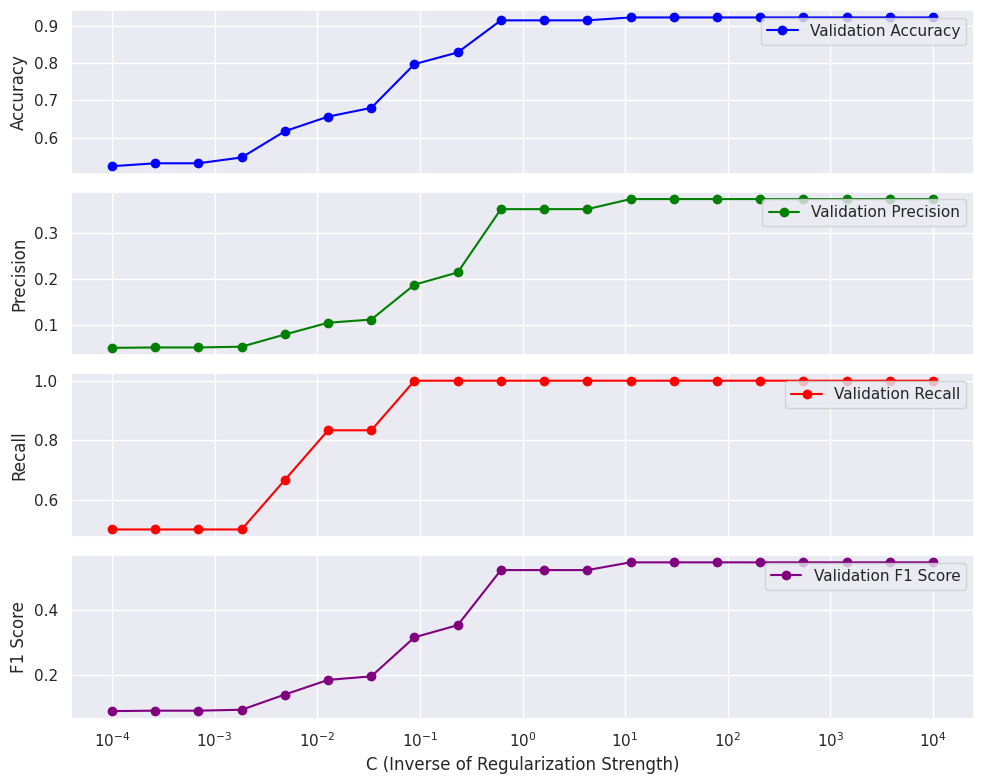

```
Best C value based on F1 score: 11.2884
Accuracy: 0.9297
Precision: 0.4000
Recall: 1.0000
F1 Score: 0.5714
ROC: 0.9617
---------------------------//--------------------------
```

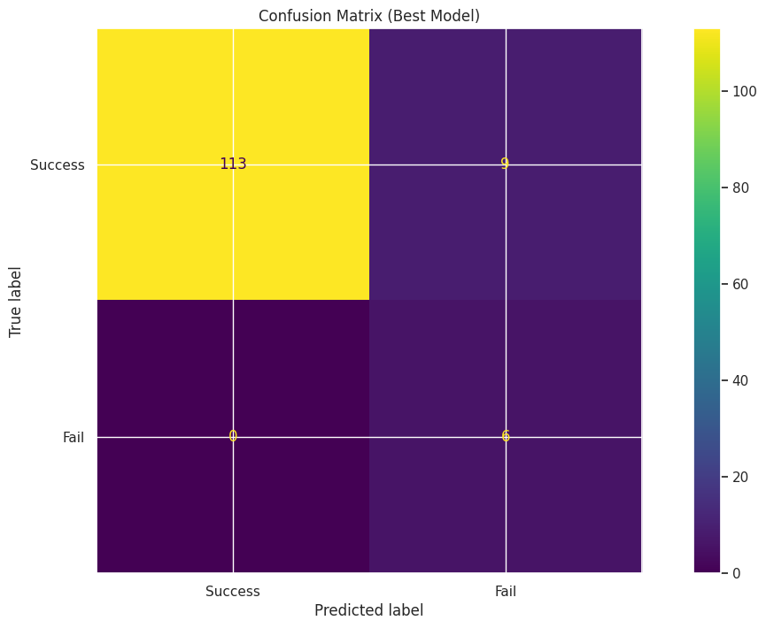

```python
# Initialize the Logistic Regression Classifier
model = LogisticRegression(random_state=42, solver='liblinear') # 'liblinear' is good for small datasets and binary classification

# Train the model
# Logistic Regression doesn't have a max_depth parameter, so we'll iterate through regularization strengths (C) instead
# Let's use a range of C values (inverse of regularization strength)
values = np.logspace(-4, 4, 20) # 20 values between 10^-4 and 10^4

# Metrics List
acc_scores = list()
prec_scores = list()
recall_scores = list()
f1_scores = list()
roc_auc_scores = list()

for c_value in values:
  model = LogisticRegression(C=c_value, random_state=42, solver='liblinear')
  model.fit(X_train_resampled, y_train_resampled)
  y_val_pred = model.predict(X_val)

  # Calculate evaluation metrics using the validation set
  accuracy = accuracy_score(y_val, y_val_pred)
  precision = precision_score(y_val, y_val_pred)
  recall = recall_score(y_val, y_val_pred)
  f1 = f1_score(y_val, y_val_pred)
  roc_auc = roc_auc_score(y_val, model.predict_proba(X_val)[:, 1])


  acc_scores.append(accuracy)
  prec_scores.append(precision)
  recall_scores.append(recall)
  f1_scores.append(f1)
  roc_auc_scores.append(roc_auc)

# Define the metrics for evaluation
scoring = ['accuracy', 'precision', 'recall', 'f1', 'roc_auc']

# Perform cross-validation
cv_results = cross_validate(
    model,
    X_train_resampled,
    y_train_resampled,
    cv=5,  # Using 5 folds for cross-validation
    scoring=scoring,
    return_train_score=False  # We are interested in validation scores
)

# Print the cross-validation results
print("Cross-validation results:")
for metric in scoring:
    mean_score = cv_results[f'test_{metric}'].mean()
    std_score = cv_results[f'test_{metric}'].std()
    print(f"{metric}: {mean_score:.4f} +/- {std_score:.4f}")

## plot of train and test scores vs C value (regularization strength)
fig, axes = plt.subplots(4, 1, figsize=(10, 8), sharex=True)

metrics = {
    'Accuracy': acc_scores,
    'Precision': prec_scores,
    'Recall': recall_scores,
    'F1 Score': f1_scores
}

colors = ['blue', 'green', 'red', 'purple']

for i, (metric_name, metric_values) in enumerate(metrics.items()):
    axes[i].plot(values, metric_values, '-o', label=f'Validation {metric_name}', color=colors[i])
    axes[i].set_ylabel(metric_name)
    axes[i].legend()
    if i == len(metrics) - 1:
        axes[i].set_xlabel('C (Inverse of Regularization Strength)')
        axes[i].set_xscale('log') # Use log scale for C values

plt.tight_layout()
plt.show()

# Display confusion matrix for the best performing model (based on F1 score for example, or choose a specific C)
# Let's pick the C value that gives the highest F1 score on the validation set
best_c_index = np.argmax(f1_scores)
best_c_value = values[best_c_index]
print(f"\nBest C value based on F1 score: {best_c_value:.4f}")

model_best = LogisticRegression(C=3, random_state=42, solver='liblinear')
model_best.fit(np.concatenate( (X_train_resampled, X_val) ), np.concatenate((y_train_resampled, y_val)))
y_val_pred = model_best.predict(X_val)

# Calculate evaluation metrics using the validation set
accuracy = accuracy_score(y_val, y_val_pred)
precision = precision_score(y_val, y_val_pred)
recall = recall_score(y_val, y_val_pred)
f1 = f1_score(y_val, y_val_pred)
roc_auc = roc_auc_score(y_val, model_best.predict_proba(X_val)[:, 1]) # ROC AUC needs probabilities
print(f"Accuracy: {accuracy:.4f}")
print(f"Precision: {precision:.4f}")
print(f"Recall: {recall:.4f}")
print(f"F1 Score: {f1:.4f}")
print(f"ROC: {roc_auc:.4f}")
print('---------------------------//--------------------------\n\n')

cm = confusion_matrix(y_val, y_val_pred)
disp = ConfusionMatrixDisplay(confusion_matrix=cm, display_labels=['Success', 'Fail'])
disp.plot()
plt.title('Confusion Matrix (Best Model)')
plt.show()
```

```python
# Prepare the test set

# Apply the same feature engineering to the test set as was applied to the training set
df_test['Vibration_RMS'] = np.sqrt(df_test['VibrationX']**2 + df_test['VibrationY']**2 + df_test['VibrationZ']**2)
df_test['Temp_Pressure'] = df_test['Temperature'] * (df_test['Pressure'])
df_test['Preset_1'] = df_test['Preset_1'].astype(int)
df_test['Preset_2'] = df_test['Preset_2'].astype(int)


X_test = df_test[final_decision]
y_test = df_test["Fail"]

# Evaluate Decision Tree
y_test_pred_dt = model_last.predict(X_test)
accuracy_dt = accuracy_score(y_test, y_test_pred_dt)
precision_dt = precision_score(y_test, y_test_pred_dt)
recall_dt = recall_score(y_test, y_test_pred_dt)
f1_dt = f1_score(y_test, y_test_pred_dt)
roc_auc_dt = roc_auc_score(y_test, model_last.predict_proba(X_test)[:, 1])

print("Decision Tree Results on Test Set:")
print(f"Accuracy: {accuracy_dt:.4f}")
print(f"Precision: {precision_dt:.4f}")
print(f"Recall: {recall_dt:.4f}")
print(f"F1 Score: {f1_dt:.4f}")
print(f"ROC AUC: {roc_auc_dt:.4f}")
print('---------------------------------------------------\n')

# Evaluate RandomForest
y_test_pred_rf = model.predict(X_test)
accuracy_rf = accuracy_score(y_test, y_test_pred_rf)
precision_rf = precision_score(y_test, y_test_pred_rf)
recall_rf = recall_score(y_test, y_test_pred_rf)
f1_rf = f1_score(y_test, y_test_pred_rf)
roc_auc_rf = roc_auc_score(y_test, model.predict_proba(X_test)[:, 1])

print("RandomForest Results on Test Set:")
print(f"Accuracy: {accuracy_rf:.4f}")
print(f"Precision: {precision_rf:.4f}")
print(f"Recall: {recall_rf:.4f}")
print(f"F1 Score: {f1_rf:.4f}")
print(f"ROC AUC: {roc_auc_rf:.4f}")
print('---------------------------------------------------\n')

# Evaluate XGBoost
y_test_pred_xgb = model_last.predict(X_test)
accuracy_xgb = accuracy_score(y_test, y_test_pred_xgb)
precision_xgb = precision_score(y_test, y_test_pred_xgb)
recall_xgb = recall_score(y_test, y_test_pred_xgb)
f1_xgb = f1_score(y_test, y_test_pred_xgb)
roc_auc_xgb = roc_auc_score(y_test, model_last.predict_proba(X_test)[:, 1])

print("XGBoost Results on Test Set:")
print(f"Accuracy: {accuracy_xgb:.4f}")
print(f"Precision: {precision_xgb:.4f}")
print(f"Recall: {recall_xgb:.4f}")
print(f"F1 Score: {f1_xgb:.4f}")
print(f"ROC AUC: {roc_auc_xgb:.4f}")
print('---------------------------------------------------\n')

# Evaluate Logistic Regression
y_test_pred_lr = model_best.predict(X_test)
accuracy_lr = accuracy_score(y_test, y_test_pred_lr)
precision_lr = precision_score(y_test, y_test_pred_lr)
recall_lr = recall_score(y_test, y_test_pred_lr)
f1_lr = f1_score(y_test, y_test_pred_lr)
roc_auc_lr = roc_auc_score(y_test, model_best.predict_proba(X_test)[:, 1])

print("Logistic Regression Results on Test Set:")
print(f"Accuracy: {accuracy_lr:.4f}")
print(f"Precision: {precision_lr:.4f}")
print(f"Recall: {recall_lr:.4f}")
print(f"F1 Score: {f1_lr:.4f}")
print(f"ROC AUC: {roc_auc_lr:.4f}")
print('---------------------------------------------------\n')
```

```
Decision Tree Results on Test Set:
Accuracy: 0.9313
Precision: 0.4737
Recall: 0.9000
F1 Score: 0.6207
ROC AUC: 0.9683
---------------------------------------------------

RandomForest Results on Test Set:
Accuracy: 0.9000
Precision: 0.3846
Recall: 1.0000
F1 Score: 0.5556
ROC AUC: 0.9753
---------------------------------------------------

XGBoost Results on Test Set:
Accuracy: 0.9313
Precision: 0.4737
Recall: 0.9000
F1 Score: 0.6207
ROC AUC: 0.9683
---------------------------------------------------

Logistic Regression Results on Test Set:
Accuracy: 0.9187
Precision: 0.4348
Recall: 1.0000
F1 Score: 0.6061
ROC AUC: 0.9753
---------------------------------------------------
```

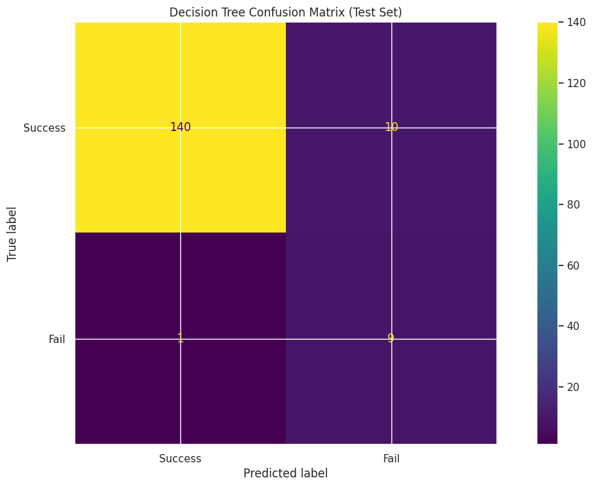

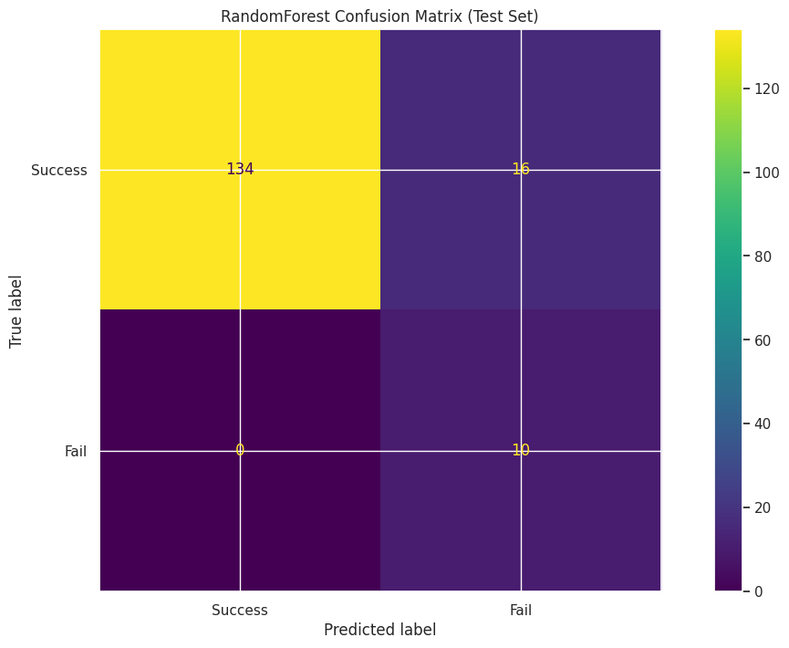

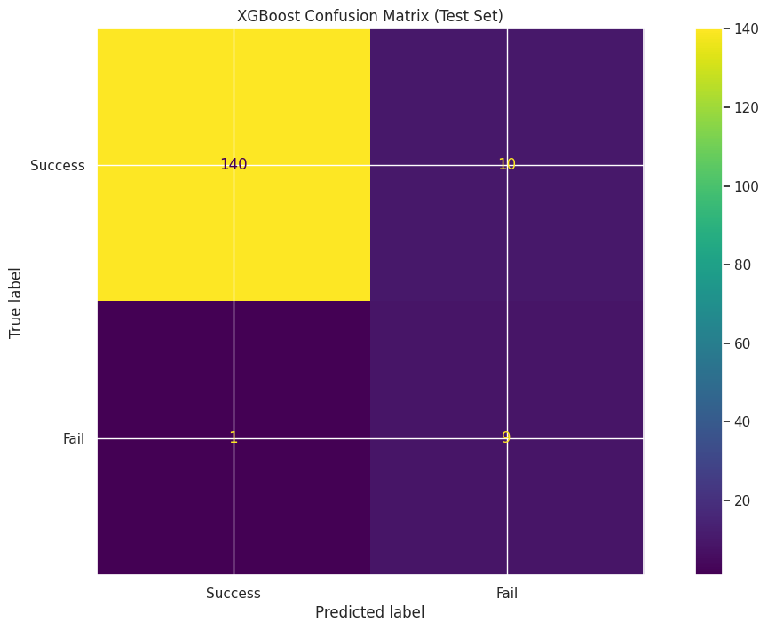

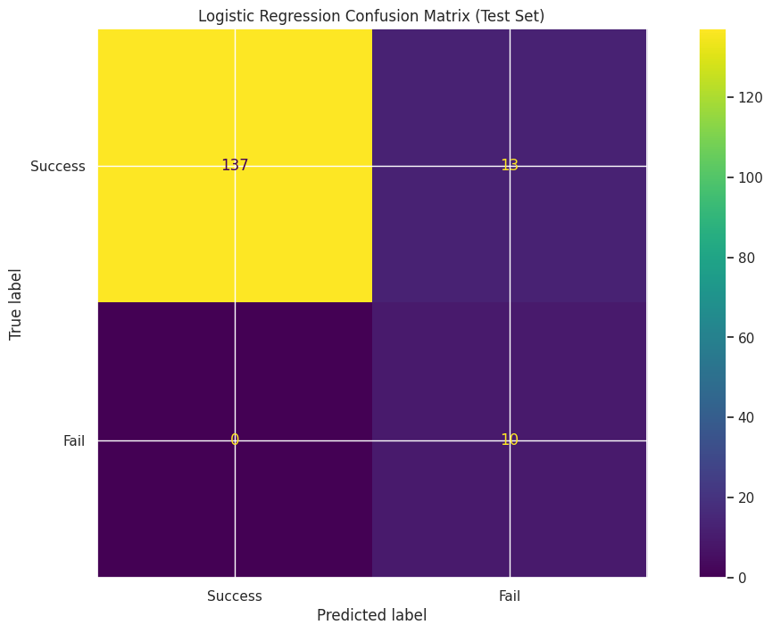

```python
# Confusion Matrix for Decision Tree
cm_dt = confusion_matrix(y_test, y_test_pred_dt)
disp_dt = ConfusionMatrixDisplay(confusion_matrix=cm_dt, display_labels=['Success', 'Fail'])
disp_dt.plot()
plt.title('Decision Tree Confusion Matrix (Test Set)')
plt.show()

# Confusion Matrix for RandomForest
cm_rf = confusion_matrix(y_test, y_test_pred_rf)
disp_rf = ConfusionMatrixDisplay(confusion_matrix=cm_rf, display_labels=['Success', 'Fail'])
disp_rf.plot()
plt.title('RandomForest Confusion Matrix (Test Set)')
plt.show()

# Confusion Matrix for XGBoost
cm_xgb = confusion_matrix(y_test, y_test_pred_xgb)
disp_xgb = ConfusionMatrixDisplay(confusion_matrix=cm_xgb, display_labels=['Success', 'Fail'])
disp_xgb.plot()
plt.title('XGBoost Confusion Matrix (Test Set)')
plt.show()

# Confusion Matrix for Logistic Regression
cm_lr = confusion_matrix(y_test, y_test_pred_lr)
disp_lr = ConfusionMatrixDisplay(confusion_matrix=cm_lr, display_labels=['Success', 'Fail'])
disp_lr.plot()
plt.title('Logistic Regression Confusion Matrix (Test Set)')
plt.show()
```

I selected Logistic Regression as one of the final models primarily because of its interpretability, robustness, and ability to provide probability estimates. In the context of equipment failure detection, false negatives are particularly dangerous, as they mean we fail to predict an actual failure — which could lead to operational disruption or safety issues.

With Logistic Regression, we can fine-tune the decision threshold to favor high recall, ensuring we catch nearly all potential failures. Even if this leads to more false positives (false alarms), it is a safer and more conservative approach for this kind of industrial application.

```python
# Get the probability scores for the positive class (Fail = 1)
y_scores_lr = model_best.predict_proba(X_test)[:, 1]

print("Evaluating Logistic Regression with different thresholds:")
# Test thresholds
for thresh in [0.2, 0.3, 0.4, 0.5, 0.6, 0.7]:
    y_pred_thresh = (y_scores_lr >= thresh).astype(int)
    p = precision_score(y_test, y_pred_thresh)
    r = recall_score(y_test, y_pred_thresh)
    f1 = f1_score(y_test, y_pred_thresh)
    print(f"Threshold: {thresh:.2f} | Precision: {p:.2f} | Recall: {r:.2f} | F1: {f1:.2f}")
```

```
Evaluating Logistic Regression with different thresholds:
Threshold: 0.20 | Precision: 0.15 | Recall: 1.00 | F1: 0.27
Threshold: 0.30 | Precision: 0.20 | Recall: 1.00 | F1: 0.33
Threshold: 0.40 | Precision: 0.33 | Recall: 1.00 | F1: 0.50
Threshold: 0.50 | Precision: 0.43 | Recall: 1.00 | F1: 0.61
Threshold: 0.60 | Precision: 0.50 | Recall: 1.00 | F1: 0.67
Threshold: 0.70 | Precision: 0.47 | Recall: 0.90 | F1: 0.62
```

By default, logistic regression uses a 0.5 threshold to classify outcomes. However, in imbalanced problems like this one, where equipment failure is rare, adjusting the threshold can significantly improve performance on the minority class.

**Here’s what I observed:**

```python
coeffs = pd.Series(model.coef_[0], index=X_train.columns)
coeffs = coeffs.sort_values(key=abs, ascending=False)  # ordena por magnitude
print(coeffs)
```

```
Vibration_RMS    0.039834
Frequency        0.033049
Temp_Pressure    0.000214
dtype: float64
```

These values indicate the strength and direction of the relationship between each feature and the probability of failure.

This analysis supports model transparency and can guide domain experts in understanding sensor relevance.

# 7.0 Hyperparemeter Fine Tuning

```python
# Define the parameter grid for Logistic Regression
param_grid_lr = {
    'C': np.logspace(-4, 4, 20), # Inverse of regularization strength
    'solver': ['liblinear'] # Suitable for small datasets
}

# Initialize GridSearchCV with Logistic Regression model
grid_search_lr = GridSearchCV(
    estimator=LogisticRegression(random_state=42),
    param_grid=param_grid_lr,
    cv=5, # 5-fold cross-validation
    scoring='f1', # Optimize for F1 score
    n_jobs=-1 # Use all available cores
)

# Fit GridSearchCV to the resampled training data
grid_search_lr.fit(X_train_resampled, y_train_resampled)

# Get the best parameters and best score
best_params_lr = grid_search_lr.best_params_
best_score_lr = grid_search_lr.best_score_

print("Best hyperparameters for Logistic Regression:")
print(best_params_lr)
print(f"Best F1 score on resampled training data: {best_score_lr:.4f}")
```

```
Best hyperparameters for Logistic Regression:
{'C': np.float64(545.5594781168514), 'solver': 'liblinear'}
Best F1 score on resampled training data: 0.9446
```

To improve performance and prevent underfitting or overfitting, I performed hyperparameter tuning using cross-validation. For Logistic Regression, the most relevant hyperparameter is C, the inverse of regularization strength.

A grid search was used to find the best C value based on F1 score.

This value reflects a balanced regularization, allowing the model to capture meaningful patterns without overfitting to noise.

# 8.0 Algorithm Evaluation

[output not shown]

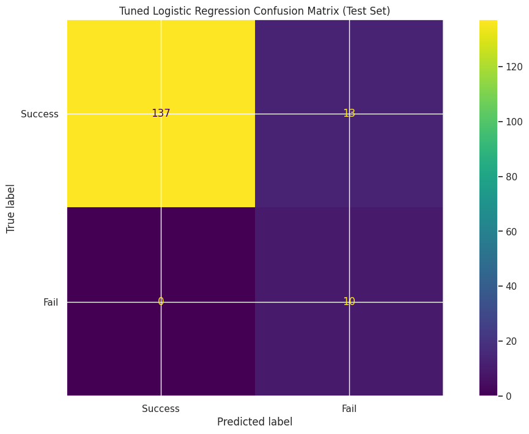

```python
# Get the best hyperparameters from the GridSearchCV result
best_params = grid_search_lr.best_params_

# Train the final Logistic Regression model using the best hyperparameters on the combined training and validation data
model_tuned_lr = LogisticRegression(random_state=42, **best_params)
model_tuned_lr.fit(np.concatenate( (X_train_resampled, X_val) ), np.concatenate((y_train_resampled, y_val)))

# Prepare the test set (assuming feature engineering and selection were already applied)
# If not already done, apply the same feature engineering and selection to df_test
df_test['Vibration_RMS'] = np.sqrt(df_test['VibrationX']**2 + df_test['VibrationY']**2 + df_test['VibrationZ']**2)
df_test['Temp_Pressure'] = df_test['Temperature'] * (df_test['Pressure'])
df_test['Preset_1'] = df_test['Preset_1'].astype(int)
df_test['Preset_2'] = df_test['Preset_2'].astype(int)
X_test = df_test[final_decision]
y_test = df_test["Fail"]


X_test = df_test[final_decision]
y_test = df_test["Fail"]


# Evaluate the tuned Logistic Regression model on the test set
y_test_pred_tuned_lr = model_tuned_lr.predict(X_test)
y_test_proba_tuned_lr = model_tuned_lr.predict_proba(X_test)[:, 1] # Probabilities for ROC AUC

accuracy_tuned_lr = accuracy_score(y_test, y_test_pred_tuned_lr)
precision_tuned_lr = precision_score(y_test, y_test_pred_tuned_lr)
recall_tuned_lr = recall_score(y_test, y_test_pred_tuned_lr)
f1_tuned_lr = f1_score(y_test, y_test_pred_tuned_lr)
roc_auc_tuned_lr = roc_auc_score(y_test, y_test_proba_tuned_lr)

print("Tuned Logistic Regression Results on Test Set:")
print(f"Accuracy: {accuracy_tuned_lr:.4f}")
print(f"Precision: {precision_tuned_lr:.4f}")
print(f"Recall: {recall_tuned_lr:.4f}")
print(f"F1 Score: {f1_tuned_lr:.4f}")
print(f"ROC AUC: {roc_auc_tuned_lr:.4f}")
print('---------------------------------------------------\n')

# Display confusion matrix for the tuned Logistic Regression model on the test set
cm_tuned_lr = confusion_matrix(y_test, y_test_pred_tuned_lr)
disp_tuned_lr = ConfusionMatrixDisplay(confusion_matrix=cm_tuned_lr, display_labels=['Success', 'Fail'])
disp_tuned_lr.plot()
plt.title('Tuned Logistic Regression Confusion Matrix (Test Set)')
plt.show()
```

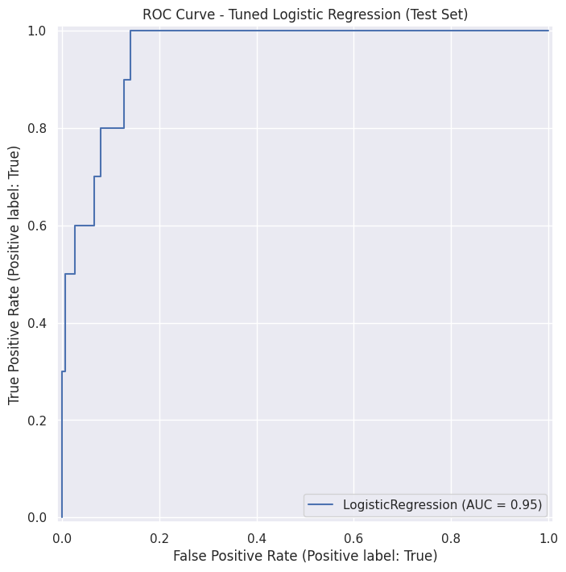

```python
# Plot ROC curve for the tuned Logistic Regression model on the test set
roc_curve_disp = RocCurveDisplay.from_estimator(model_tuned_lr, X_test, y_test)
# roc_curve_disp.plot()
plt.title('ROC Curve - Tuned Logistic Regression (Test Set)')
plt.show()
```

# 9.0 Analyze variable importance

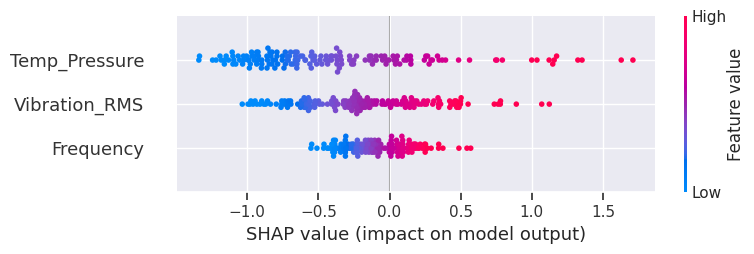

```python
# Explain the model's predictions using SHAP
# For linear models like Logistic Regression, we can use the LinearExplainer
explainer = shap.LinearExplainer(model_tuned_lr, X_train_resampled)
shap_values = explainer.shap_values(X_test)

# Visualize the feature importances using a summary plot
shap.summary_plot(shap_values, X_test, feature_names=X_test.columns)
```

📊 Variable Interpretation:

🔹 Temp_Pressure Low values (dark blue) tend to decrease the probability of failure (negative SHAP values).

High values (red) indicate an increased risk of failure.

Interpretation: The combination of high temperature and high pressure appears to be associated with a high risk of failure.

🔹 Vibration_RMS Similar behavior: high values (red) are associated with positive SHAP values, meaning they increase the risk of failure.

Total vibration (in all possible ranges) is a good predictor of failure, especially when it is high.

🔹 Frequency Also shows that high operating frequencies (red) are associated with a higher risk of failure.

Lower frequencies (blue) are generally associated with SHAP values close to zero or even negative.

✅ Graph Conclusion This graph shows that:

The chosen variables are indeed contributing to the model's failure identification.

High values for Temp_Pressure, Vibration_RMS, and Frequency are strong indicators of failure risk.

The model's explainability is in line with what is expected in the operational context of industrial machinery: vibration, frequency, and pressure directly influence the safe operation of equipment.

# 10.0 ROI

In offshore Oil & Gas operations, unplanned equipment failures in FPSOs (Floating Production Storage and Offloading vessels) can lead to substantial financial losses. These include:

- Production shutdowns: USD 1M–3M per day
- Corrective maintenance & mobilization: USD 100K–500K
- Environmental or safety incidents: Penalties in the millions

Reputation and contractual losses

📌 According to industry sources (Wood Mackenzie, McKinsey Oil & Gas Insights, Petrobras reports), a single critical equipment failure can result in a loss of USD 2M to 5M.

🧠 Model Impact – Why Recall Matters Our tuned Logistic Regression model achieves:

- Recall = 1.00 → all real failures are correctly predicted (no false negatives)
- This allows maintenance teams to act before failures occur, shifting from reactive to predictive maintenance.
- Although the model shows lower precision (≈43%), meaning some false alarms may occur, this trade-off is acceptable in high-risk environments.

✅ In safety-critical industries, it's better to over-alert than to miss a real failure.

💸 Cost Avoidance Estimate Assuming the asset experiences 5 critical failures per year, each costing an average of USD 2M:

Without predictive model:

- **5 failures x USD 2M = USD 10M/year in losses**

With our model (Recall = 1.0):

- **0 unpredicted failures → up to USD 10M/year saved**

Even accounting for the cost of false positives (extra inspections), the savings from avoided failures far outweigh the additional operational cost.

✅ Conclusion:

This model adds measurable business value by preventing all known failures in advance. Its implementation can potentially avoid millions of dollars in annual losses, improve operational continuity, and enhance safety — making it a strong candidate for deployment in production environments.